# mtcars Dataset Analysis

Marvin Marino

Wednesday, November 19, 2014

### Preamble:

This document focuses on the analysis of the R dataset mtcars.

Description of dataset mtcars can be found in internet. Link: https://stat.ethz.ch/R-manual/R-devel/library/datasets/html/mtcars.html

### Research questions:

- Question 1: is a car with automatic or manual transmission better in term of miles per gallons (mpg)?
- Question 2: quantify the mpg difference between automatic and manual transmission.

### Analysis structure:

I will address both issues from different angles employing a set of methodologies that can be broadly grouped as follows:

1. Univariate analysis on target variable (mpg).
2. Bivariate analysis on target variable and relevant covariates.
3. Multivariate analysis: estimation a set of regression models for the conditional mean of mpg. For model selection, I compare the Best Fit and Forward Stepwise Selection procedures.

### Chapter 1. Univariate analysis

In this chapter I focus on analyzing the target variable (mpg) alone by splitting the observations into two groups, i.e. cars wtih automatic or manual transmission. I will execute 3 analysis:

1. Compute sample means by group (i.e. transmission automatic vs. manual).
2. Validate if the difference of the group means is statistically significant by computing a 95% confidence interval for means difference.
3. Verify the robustness of this result by executing a permutation test with Monte Carlo trials that shuffle the allocation group > mpg.

### 1.1 Sample means by group

Initially a perform a subset of the data by group.

```r
#### generate subset: automatic and manual cars ####
cars_auto = subset(mtcars, am == 0)
cars_manu = subset(mtcars, am == 1)

# dimensions
dim(mtcars)
```

```
## [1] 32 11
```

```r
dim(cars_auto); dim(cars_manu)
```

```
## [1] 19 11
```

```
## [1] 13 11
```

```r
# sample means mpg by group
mean(cars_auto$mpg); mean(cars_manu$mpg)
```

```
## [1] 17.14737
```

```
## [1] 24.39231
```

```r
sd(cars_auto$mpg); sd(cars_manu$mpg)
```

```
## [1] 3.833966
```

```
## [1] 6.166504
```

```r
# % increase in mpg based on the sample mean
(mean(cars_manu$mpg) - mean(cars_auto$mpg))/mean(cars_auto$mpg)
```

```
## [1] 0.4225103
```

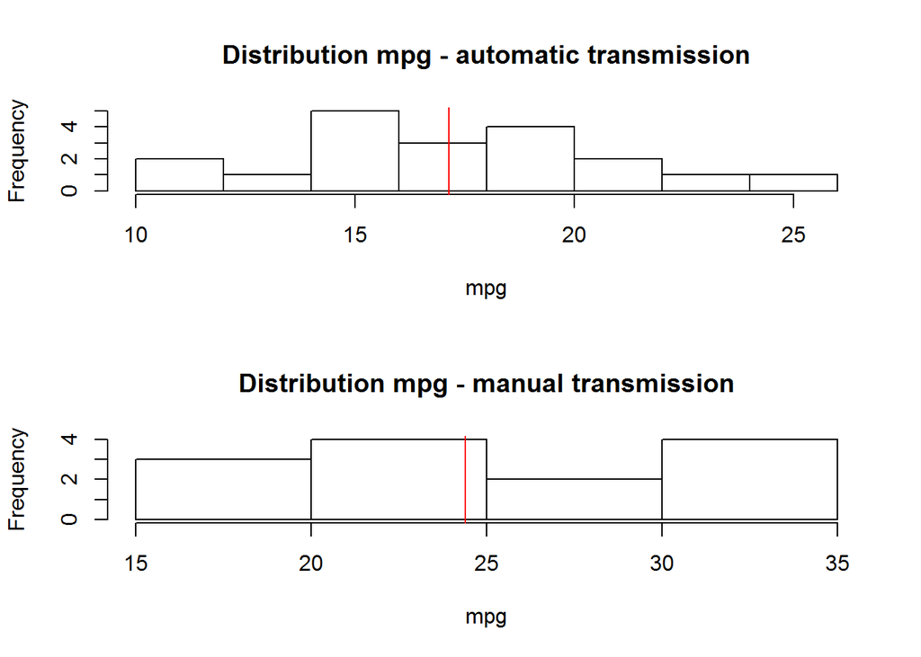

```r
#### mpg plots ####
par(mfrow = c(2, 1))
hist(cars_auto$mpg, main = "Distribution mpg - automatic transmission", xlab = "mpg")
abline(v = mean(cars_auto$mpg), col = "red")
hist(cars_manu$mpg, main = "Distribution mpg - manual transmission", xlab = "mpg")
abline(v = mean(cars_manu$mpg), col = "red")
```

Conclusions:

- mpg empirical mean of cars with manual transmission is greater than cars with automatic transmission, however has also higher variance.
- `Based on this result alone can be concluded that on average cars with manual transmission have 42% mileage than cars with automatic transmission. >>> is correct to conclude this?`